# 金融大數據期末報告: 外匯三角套利與利差套利分析

作者: 109071015 QF24 張晁維

日期: 2023-06-17

# 壹、研究主題

#### 本主題旨在分析國際外匯市場中的主流貨幣間是否存在三角套利與利差套利空間，首先是將套利的判斷建模；其次是不同貨幣的套利組合與套利空間重分類的視覺化比較；第三是不同套利模式下，子群體之間的變異數分析(ANOVA)；另外在互動區中還有套利空間分布與常見機率分配函數，如Chi-square，的比較；最後以Shiny套件、rsconnect套件建構可互動、獨立於本HTML之操作介面，讓使用者可迅速、精確地獲取指定資訊，且可從網站shinyapps.io上操作互動式頁面。

# 貳、研究動機

#### 外匯交易的存在仰賴於持續變化、波動的外匯市場，這在固定匯率或是高度管理匯率的時代所不敢想像的，而其中所藏的套利空間更是為投資人所垂涎，我認為這正是它吸引人處，例如為世人所津津樂道的渡邊太太。學生在大二下學期時曾修習曾祺峰教授所開的國際財務管理一課，其中學到許多關於外匯的知識，因此藉這次的機會將許多繁雜的計算、判斷程式化，且使其適用於大數據的運算，而非僅止於單筆計算、判斷，並且加入與常見的機率分布的比較與視覺化的呈現，增強使用者在比較套利空間上的需求。

# 參、研究目標

#### (i) 建立適用於大數據計算、輸入數據僅需簡單預處理的函數

#### (ii) 建立從不同視角下的視覺化比較

#### (iii) 建立與常見機率分布的視覺化比較

#### (iv) 建立分離、獨立的互動式工具

# 肆、資料選擇與資料描述

# 伍、研究分析與結果

## 1. 外匯三角套利

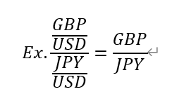

### (ii)資料引入與整理: 2022/1/1 ~ 2022/12/31；頻率: 日；共計260筆資料。

#### a.資料母群體

```r
data1 <- read.csv("FX_data.csv")

kable(data1) %>% kable_styling() %>% scroll_box(height="150px")
```

| Date | GBP_JPY | GBP_TWD | GBP_EUR | TWD_JPY | EUR_JPY | GBP_USD | JPY_USD | TWD_USD | EUR_USD |
| --- | --- | --- | --- | --- | --- | --- | --- | --- | --- |
| 01/03/2022 | 155.35 | 37.230 | 1.1923 | 4.1712 | 130.24 | 1.3471 | 0.008670 | 0.03617 | 1.1294 |
| 01/04/2022 | 157.10 | 37.243 | 1.1983 | 4.2168 | 131.05 | 1.3532 | 0.008608 | 0.03631 | 1.1285 |
| 01/05/2022 | 157.36 | 37.420 | 1.1977 | 4.2038 | 131.34 | 1.3554 | 0.008611 | 0.03621 | 1.1313 |
| 01/06/2022 | 156.68 | 37.423 | 1.1977 | 4.1853 | 130.77 | 1.3528 | 0.008632 | 0.03614 | 1.1291 |
| 01/07/2022 | 156.97 | 37.501 | 1.1955 | 4.1813 | 131.25 | 1.3585 | 0.008652 | 0.03619 | 1.1359 |
| 01/10/2022 | 156.41 | 37.549 | 1.1985 | 4.1609 | 130.45 | 1.3575 | 0.008678 | 0.03612 | 1.1324 |
| 01/11/2022 | 157.17 | 37.716 | 1.1993 | 4.1628 | 131.03 | 1.3635 | 0.008673 | 0.03611 | 1.1364 |
| 01/12/2022 | 157.05 | 37.879 | 1.1970 | 4.1417 | 131.16 | 1.3701 | 0.008723 | 0.03613 | 1.1442 |
| 01/13/2022 | 156.48 | 37.874 | 1.1962 | 4.1287 | 130.77 | 1.3705 | 0.008756 | 0.03616 | 1.1453 |
| 01/14/2022 | 156.15 | 37.655 | 1.1975 | 4.1452 | 130.35 | 1.3673 | 0.008754 | 0.03630 | 1.1414 |
| 01/17/2022 | 156.37 | 37.535 | 1.1958 | 4.1615 | 130.72 | 1.3645 | 0.008723 | 0.03631 | 1.1407 |
| 01/18/2022 | 155.80 | 37.438 | 1.1999 | 4.1480 | 129.80 | 1.3594 | 0.008724 | 0.03619 | 1.1325 |
| 01/19/2022 | 155.54 | 37.584 | 1.1994 | 4.1341 | 129.65 | 1.3606 | 0.008745 | 0.03616 | 1.1341 |
| 01/20/2022 | 155.11 | 37.554 | 1.2016 | 4.1258 | 129.04 | 1.3595 | 0.008763 | 0.03616 | 1.1310 |
| 01/21/2022 | 154.08 | 37.534 | 1.1948 | 4.1007 | 128.91 | 1.3554 | 0.008794 | 0.03607 | 1.1340 |
| 01/24/2022 | 153.62 | 37.328 | 1.1905 | 4.1089 | 128.99 | 1.3485 | 0.008776 | 0.03607 | 1.1323 |
| 01/25/2022 | 153.71 | 37.413 | 1.1944 | 4.1071 | 128.65 | 1.3496 | 0.008780 | 0.03607 | 1.1299 |
| 01/26/2022 | 154.30 | 37.342 | 1.1975 | 4.1277 | 128.81 | 1.3461 | 0.008721 | 0.03601 | 1.1237 |
| 01/27/2022 | 154.38 | 37.218 | 1.2008 | 4.1436 | 128.52 | 1.3385 | 0.008666 | 0.03593 | 1.1143 |
| 01/28/2022 | 154.47 | 37.299 | 1.2025 | 4.1368 | 128.41 | 1.3404 | 0.008675 | 0.03590 | 1.1143 |
| 01/31/2022 | 154.75 | 37.335 | 1.1965 | 4.1398 | 129.29 | 1.3445 | 0.008686 | 0.03597 | 1.1233 |
| 02/01/2022 | 155.09 | 37.565 | 1.1993 | 4.1240 | 129.27 | 1.3520 | 0.008715 | 0.03595 | 1.1269 |
| 02/02/2022 | 155.39 | 37.740 | 1.2010 | 4.1143 | 129.34 | 1.3577 | 0.008736 | 0.03595 | 1.1303 |
| 02/03/2022 | 156.31 | 37.760 | 1.1883 | 4.1352 | 131.50 | 1.3595 | 0.008696 | 0.03597 | 1.1438 |
| 02/04/2022 | 155.85 | 37.609 | 1.1816 | 4.1396 | 131.86 | 1.3529 | 0.008678 | 0.03593 | 1.1446 |
| 02/07/2022 | 155.80 | 37.684 | 1.1827 | 4.1330 | 131.72 | 1.3534 | 0.008684 | 0.03590 | 1.1442 |
| 02/08/2022 | 156.45 | 37.658 | 1.1861 | 4.1501 | 131.88 | 1.3541 | 0.008654 | 0.03592 | 1.1414 |
| 02/09/2022 | 156.28 | 37.595 | 1.1843 | 4.1525 | 131.91 | 1.3532 | 0.008657 | 0.03596 | 1.1422 |
| 02/10/2022 | 157.24 | 37.749 | 1.1861 | 4.1608 | 132.55 | 1.3555 | 0.008618 | 0.03587 | 1.1427 |
| 02/11/2022 | 156.50 | 37.823 | 1.1944 | 4.1332 | 130.98 | 1.3560 | 0.008663 | 0.03581 | 1.1349 |

[output cut: 230 more lines]

#### b.資料基本描述

```r
kable(skim(data1)) %>% kable_styling() %>% scroll_box(height="100px")
```

| skim_type | skim_variable | n_missing | complete_rate | character.min | character.max | character.empty | character.n_unique | character.whitespace | numeric.mean | numeric.sd | numeric.p0 | numeric.p25 | numeric.p50 | numeric.p75 | numeric.p100 | numeric.hist |
| --- | --- | --- | --- | --- | --- | --- | --- | --- | --- | --- | --- | --- | --- | --- | --- | --- |
| character | Date | 0 | 1 | 10 | 10 | 0 | 260 | 0 | NA | NA | NA | NA | NA | NA | NA | NA |
| numeric | GBP_JPY | 0 | 1 | NA | NA | NA | NA | NA | 161.8575000 | 4.4713888 | 151.09000 | 159.037500 | 162.190000 | 165.3350000 | 171.190000 | ▂▃▇▇▃ |
| numeric | GBP_TWD | 0 | 1 | NA | NA | NA | NA | NA | 36.7397269 | 0.8419638 | 34.00300 | 36.102500 | 36.935500 | 37.4407500 | 38.179000 | ▁▃▆▇▇ |
| numeric | GBP_EUR | 0 | 1 | NA | NA | NA | NA | NA | 1.1728138 | 0.0219042 | 1.11170 | 1.156750 | 1.175850 | 1.1913250 | 1.210200 | ▁▅▇▇▇ |
| numeric | TWD_JPY | 0 | 1 | NA | NA | NA | NA | NA | 4.4038335 | 0.1734910 | 4.07280 | 4.281200 | 4.446450 | 4.5585750 | 4.675700 | ▆▃▅▇▇ |
| numeric | EUR_JPY | 0 | 1 | NA | NA | NA | NA | NA | 138.0406538 | 5.4682551 | 125.15000 | 134.720000 | 138.420000 | 142.5975000 | 147.480000 | ▂▅▇▇▇ |
| numeric | GBP_USD | 0 | 1 | NA | NA | NA | NA | NA | 1.2363473 | 0.0759632 | 1.06840 | 1.185650 | 1.222450 | 1.3069250 | 1.370500 | ▂▅▇▃▆ |
| numeric | JPY_USD | 0 | 1 | NA | NA | NA | NA | NA | 0.0076508 | 0.0006300 | 0.00666 | 0.007207 | 0.007471 | 0.0081013 | 0.008794 | ▅▇▅▂▅ |
| numeric | TWD_USD | 0 | 1 | NA | NA | NA | NA | NA | 0.0335954 | 0.0015042 | 0.03087 | 0.032470 | 0.033530 | 0.0348300 | 0.036310 | ▃▅▇▂▅ |
| numeric | EUR_USD | 0 | 1 | NA | NA | NA | NA | NA | 1.0531812 | 0.0497840 | 0.95920 | 1.011775 | 1.052250 | 1.0900000 | 1.145300 | ▅▇▇▅▅ |

### (iii)範例: 英鎊(GBP)對日圓(JPY)三角套利計算

```r
dat1 <- data.frame(data1["GBP_USD"]/data1["JPY_USD"])
colnames(dat1) <- c("Price")
dat2 <- round(abs(dat1["Price"] - data1["GBP_JPY"])
              , digits=4)
dat2 <- cbind(data1["Date"], dat2)
colnames(dat2) <- c("Date", "GBP_JPY")

kable(dat2) %>% kable_styling() %>% scroll_box(height="100px")
```

| Date | GBP_JPY |
| --- | --- |
| 01/03/2022 | 0.0249 |
| 01/04/2022 | 0.1026 |
| 01/05/2022 | 0.0433 |
| 01/06/2022 | 0.0392 |
| 01/07/2022 | 0.0457 |
| 01/10/2022 | 0.0201 |
| 01/11/2022 | 0.0420 |
| 01/12/2022 | 0.0175 |
| 01/13/2022 | 0.0412 |
| 01/14/2022 | 0.0415 |
| 01/17/2022 | 0.0555 |
| 01/18/2022 | 0.0230 |
| 01/19/2022 | 0.0460 |
| 01/20/2022 | 0.0309 |
| 01/21/2022 | 0.0478 |
| 01/24/2022 | 0.0377 |
| 01/25/2022 | 0.0030 |
| 01/26/2022 | 0.0516 |
| 01/27/2022 | 0.0742 |
| 01/28/2022 | 0.0430 |
| 01/31/2022 | 0.0393 |
| 02/01/2022 | 0.0448 |
| 02/02/2022 | 0.0244 |
| 02/03/2022 | 0.0262 |
| 02/04/2022 | 0.0500 |
| 02/07/2022 | 0.0498 |
| 02/08/2022 | 0.0210 |
| 02/09/2022 | 0.0328 |
| 02/10/2022 | 0.0471 |
| 02/11/2022 | 0.0278 |

[output cut: 230 more lines]

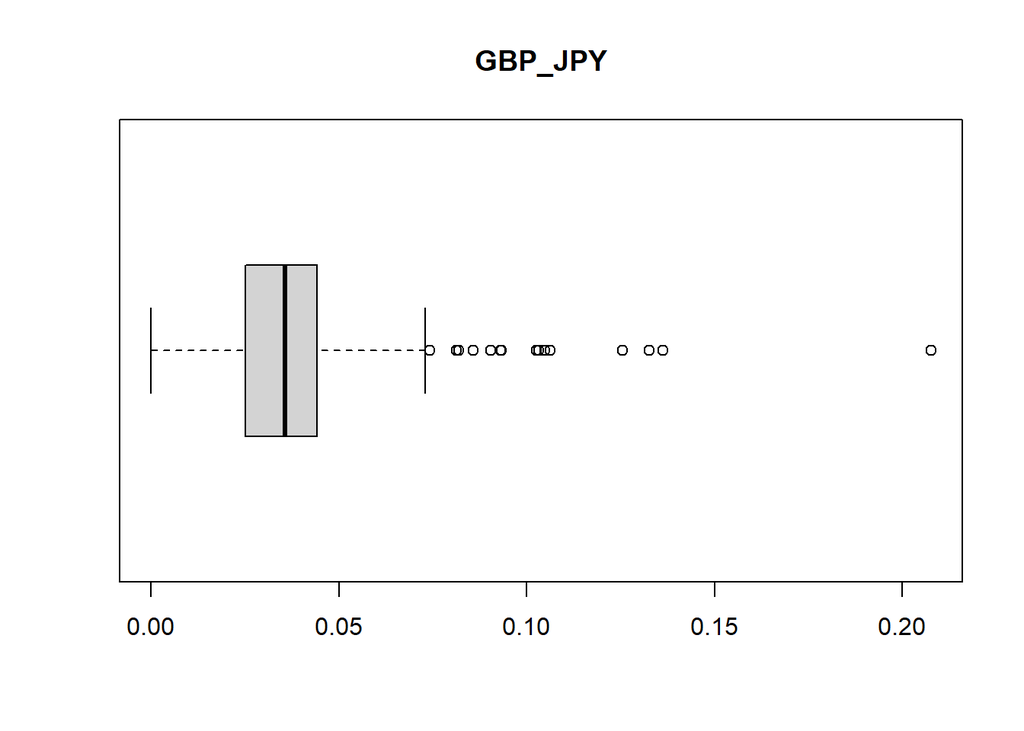

```r
boxplot(subset(dat2, select="GBP_JPY")
        , horizontal=T
        , main="GBP_JPY")
```

### (iv)函式: 計算套利空間

#### TA, Triangular Arbitrage

```r
TA <- function(data1){
  index <- colnames(data1)[2:10]
  df <- data.frame(data1["Date"])
  for(i in 1:5){
    n0 <- str_sub(index[i], start=1, end=3)
    n1 <- str_sub(index[i], start=5, end=7)
    for(j in 6:9){
      if(str_sub(index[j], start=1, end=3)==n0){
        t0 <- as.numeric(data1[, j+1])
      }else if(str_sub(index[j], start=1, end=3)==n1){
        t1 <- as.numeric(data1[, j+1])
      }
    }
    dat <- data.frame(round(abs(t0/t1-data1[, i+1])
                            , digits=4))
    df <- cbind(df, dat)
  }
  colnames(df) <- c("Date", index[1:5])
  return(df)
}
```

```r
data2 <- TA(data1)

kable(data2) %>% kable_styling() %>% scroll_box(height="100px")
```

| Date | GBP_JPY | GBP_TWD | GBP_EUR | TWD_JPY | EUR_JPY |
| --- | --- | --- | --- | --- | --- |
| 01/03/2022 | 0.0249 | 0.0136 | 0.0005 | 0.0007 | 0.0253 |
| 01/04/2022 | 0.1026 | 0.0250 | 0.0008 | 0.0014 | 0.0490 |
| 01/05/2022 | 0.0433 | 0.0116 | 0.0004 | 0.0013 | 0.0385 |
| 01/06/2022 | 0.0392 | 0.0092 | 0.0004 | 0.0014 | 0.0340 |
| 01/07/2022 | 0.0457 | 0.0370 | 0.0005 | 0.0015 | 0.0376 |
| 01/10/2022 | 0.0201 | 0.0341 | 0.0003 | 0.0013 | 0.0409 |
| 01/11/2022 | 0.0420 | 0.0436 | 0.0005 | 0.0007 | 0.0027 |
| 01/12/2022 | 0.0175 | 0.0424 | 0.0004 | 0.0002 | 0.0105 |
| 01/13/2022 | 0.0412 | 0.0270 | 0.0004 | 0.0010 | 0.0317 |
| 01/14/2022 | 0.0415 | 0.0117 | 0.0004 | 0.0015 | 0.0361 |
| 01/17/2022 | 0.0555 | 0.0442 | 0.0004 | 0.0011 | 0.0492 |
| 01/18/2022 | 0.0230 | 0.1249 | 0.0005 | 0.0003 | 0.0143 |
| 01/19/2022 | 0.0460 | 0.0432 | 0.0003 | 0.0008 | 0.0355 |
| 01/20/2022 | 0.0309 | 0.0428 | 0.0004 | 0.0006 | 0.0254 |
| 01/21/2022 | 0.0478 | 0.0429 | 0.0004 | 0.0010 | 0.0416 |
| 01/24/2022 | 0.0377 | 0.0576 | 0.0004 | 0.0012 | 0.0323 |
| 01/25/2022 | 0.0030 | 0.0031 | 0.0000 | 0.0011 | 0.0402 |
| 01/26/2022 | 0.0516 | 0.0393 | 0.0004 | 0.0014 | 0.0399 |
| 01/27/2022 | 0.0742 | 0.0350 | 0.0004 | 0.0025 | 0.0630 |
| 01/28/2022 | 0.0430 | 0.0380 | 0.0004 | 0.0015 | 0.0396 |
| 01/31/2022 | 0.0393 | 0.0434 | 0.0004 | 0.0013 | 0.0330 |
| 02/01/2022 | 0.0448 | 0.0428 | 0.0005 | 0.0011 | 0.0358 |
| 02/02/2022 | 0.0244 | 0.0263 | 0.0002 | 0.0009 | 0.0442 |
| 02/03/2022 | 0.0262 | 0.0354 | 0.0003 | 0.0012 | 0.0317 |
| 02/04/2022 | 0.0500 | 0.0448 | 0.0004 | 0.0008 | 0.0368 |
| 02/07/2022 | 0.0498 | 0.0152 | 0.0001 | 0.0010 | 0.0396 |
| 02/08/2022 | 0.0210 | 0.0397 | 0.0003 | 0.0006 | 0.0128 |
| 02/09/2022 | 0.0328 | 0.0357 | 0.0004 | 0.0014 | 0.0295 |
| 02/10/2022 | 0.0471 | 0.0402 | 0.0001 | 0.0014 | 0.0446 |
| 02/11/2022 | 0.0278 | 0.0435 | 0.0004 | 0.0005 | 0.0254 |

[output cut: 230 more lines]

#### 註: 單位為後三位字元所代表的貨幣(Ex. GBP_JPY，單位為日圓)

### (v)資料視覺化: 三角套利之套利空間分布

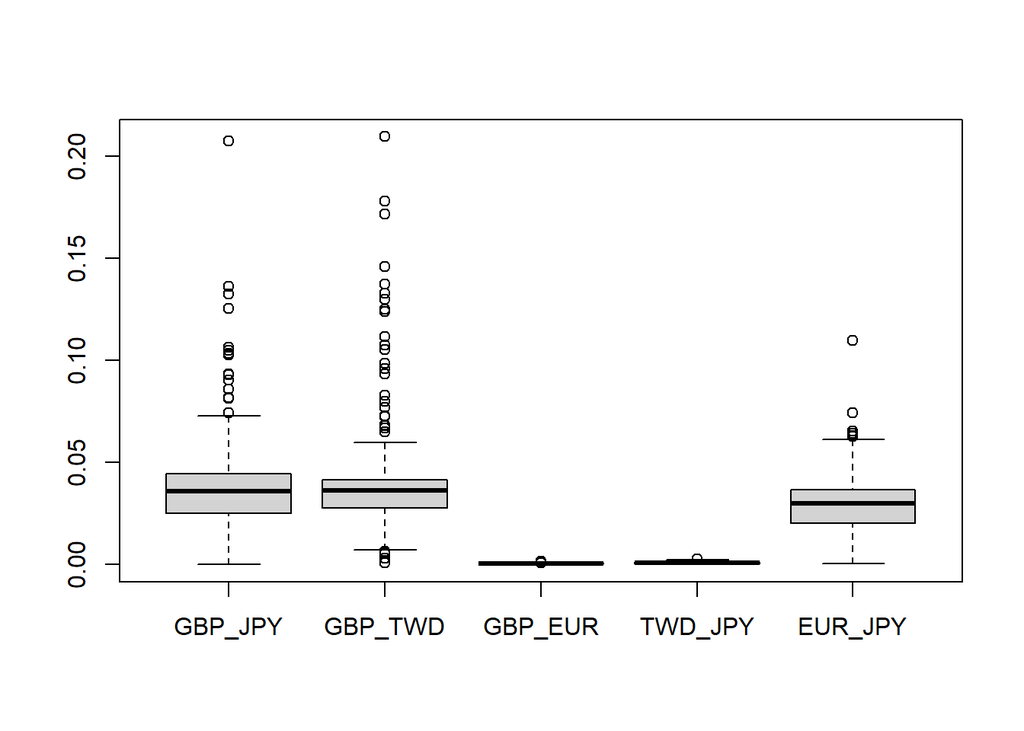

```r
boxplot(data2[2:6])
```

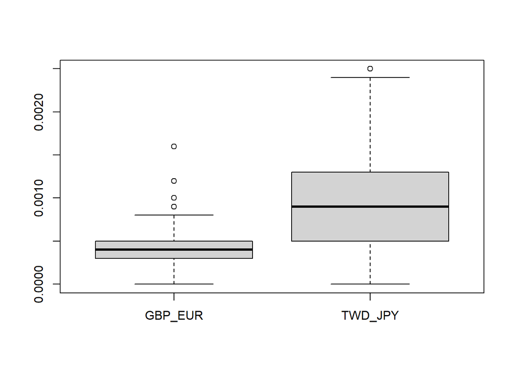

```r
boxplot(data2[4:5])
```

### (vi)資料視覺化: 套利空間占比

#### 先將套利空間以0, 0.001, 0.01, 0.1, 1分成四組，再進行不同形式的比較。

```r
datatemp1 <- cut(data2[, 2]
                , breaks=c(0, 0.001, 0.01, 0.1, 1)
                , labels=c("0~0.001", "0.001~0.01", "0.01~0.1", "0.1~1")
                , include.lowest=T)
for(i in 3:6){
  temp <- cut(data2[, i]
                , breaks=c(0, 0.001, 0.01, 0.1, 1)
                , labels=c("0~0.001", "0.001~0.01", "0.01~0.1", "0.1~1")
                , include.lowest=T)
  datatemp1 <- data.frame(datatemp1, temp)
}
colnames(datatemp1) <- colnames(data2)[2:6]
```

```r
datatemp2 <- data.frame()
for(i in 1:5){
  datatemp2 <- rbind(datatemp2, table(datatemp1[i])/260)
}
datatemp2 <- data.frame(datatemp2)
datatemp2 <- cbind(colnames(data2)[2:6], datatemp2)
row.names(datatemp2) <- 1:5
colnames(datatemp2) <- c("combination", "0~0.001", "0.001~0.01", "0.01~0.1", "0.1~1")
```

#### a.雷達圖(ggradar)

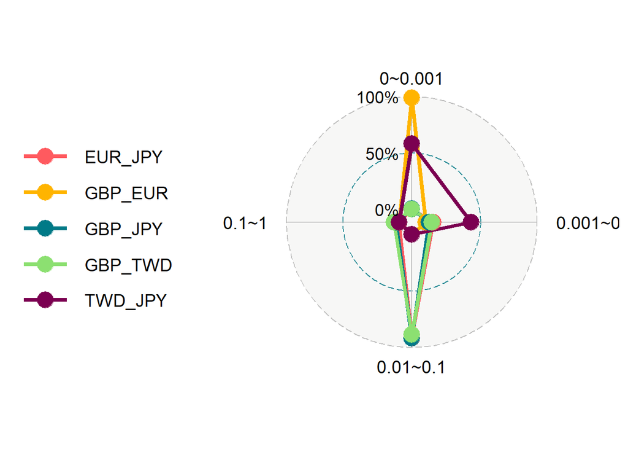

```r
datatemp2 %>% ggradar()
```

#### b.長條圖(Bar chart)

```r
temp <- table(datatemp1[, 1])
for(i in 2:5){
  temp <- rbind(temp, table(datatemp1[, i]))
}
row.names(temp) <- colnames(data2)[2:6]
```

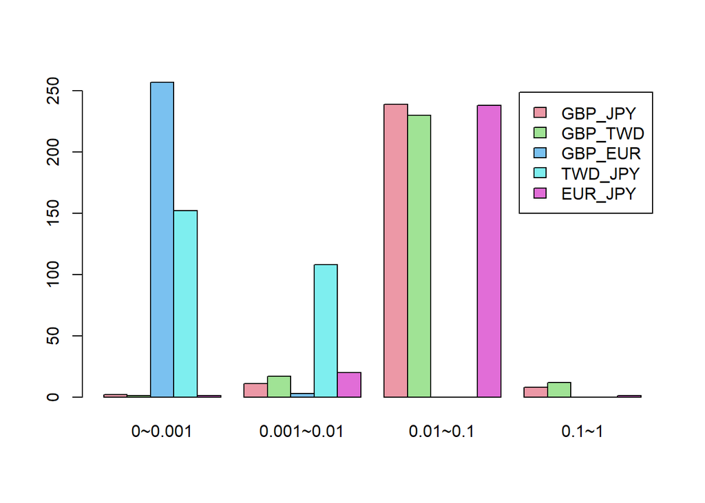

```r
temp %>% barplot(beside = T
                 , legend.text = rownames(.)
                 , col = palette("Set 3")[2:6] %>% alpha(0.6))
```

#### c.熱量圖(Heat map)

```r
datatemp3 <- data.frame()
for(i in 1:5){
  datatemp3 <- rbind(datatemp3, table(datatemp1[i])/260)
}
datatemp3 <- data.frame(datatemp3)
colnames(datatemp3) <- c("0~0.001", "0.001~0.01", "0.01~0.1", "0.1~1")
rownames(datatemp3) <- colnames(data2)[2:6]
```

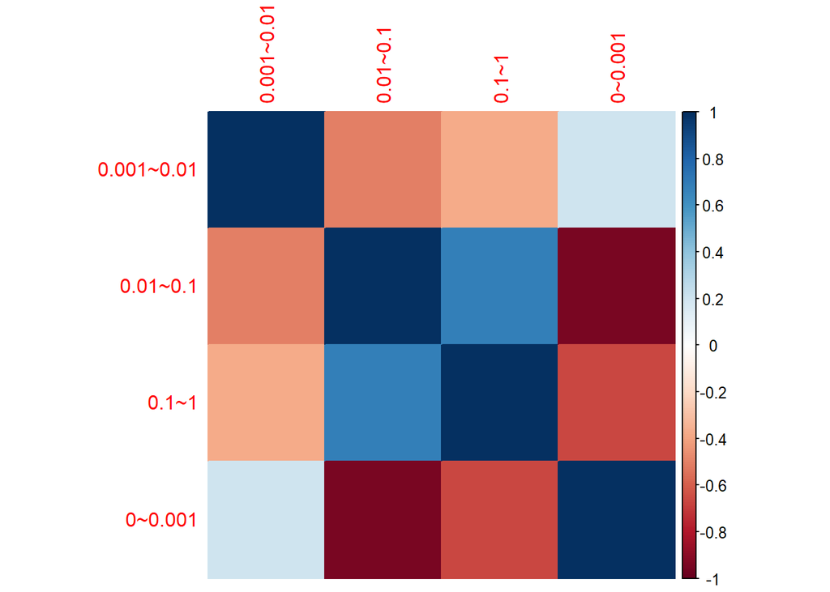

```r
corrplot(cor(datatemp3), method = 'color', order = 'alphabet')
```

### (vii)資料分析: 各貨幣組合套利空間之One-Way ANOVA

```r
fit <- lm(GBP_JPY~GBP_TWD+GBP_EUR+TWD_JPY+EUR_JPY, data=data2)
fit <- anova(fit)
kable(fit, "pipe", align = "cccc")
```

|  | Df | Sum Sq | Mean Sq | F value | Pr(>F) |
| --- | --- | --- | --- | --- | --- |
| GBP_TWD | 1 | 0.0018432 | 0.0018432 | 6.900302 | 0.0091399 |
| GBP_EUR | 1 | 0.0412687 | 0.0412687 | 154.493098 | 0.0000000 |
| TWD_JPY | 1 | 0.0163851 | 0.0163851 | 61.338922 | 0.0000000 |
| EUR_JPY | 1 | 0.0148030 | 0.0148030 | 55.416275 | 0.0000000 |
| Residuals | 255 | 0.0681164 | 0.0002671 | NA | NA |

### https://6842studio.shinyapps.io/final2/

#### (建議按右鍵以開啟新分頁)

## 2. 外匯利差套利

### (i)原理

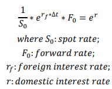

#### a.資料母群體

```r
data3 <- read.csv("Futures_Bond.csv")

kable(data3) %>% kable_styling() %>% scroll_box(height="100px")
```

| Date | CADB | FRFB | GBPB | GBP_USD | CAD_USD | EUR_USD | GBPF | CADF | EURF | USDB |
| --- | --- | --- | --- | --- | --- | --- | --- | --- | --- | --- |
| 01/02/2022 | 0.080 | -0.640 | 0.129 | 1.3585 | 0.7906 | 1.1359 | 1.3593 | 0.7914 | 0.99767 | 0.051 |
| 01/09/2022 | 0.160 | -0.634 | 0.167 | 1.3673 | 0.7964 | 1.1414 | 1.3673 | 0.7959 | 0.99757 | 0.048 |
| 01/16/2022 | 0.285 | -0.630 | 0.152 | 1.3554 | 0.7946 | 1.1340 | 1.3551 | 0.7951 | 0.99677 | 0.046 |
| 01/23/2022 | 0.165 | -0.628 | 0.228 | 1.3404 | 0.7833 | 1.1143 | 1.3381 | 0.7820 | 0.99630 | 0.043 |
| 01/30/2022 | 0.130 | -0.640 | 0.396 | 1.3529 | 0.7832 | 1.1446 | 1.3525 | 0.7840 | 0.99567 | 0.041 |
| 02/06/2022 | 0.190 | -0.632 | 0.441 | 1.3560 | 0.7851 | 1.1349 | 1.3547 | 0.7848 | 0.99525 | 0.046 |
| 02/13/2022 | 0.160 | -0.640 | 0.441 | 1.3590 | 0.7841 | 1.1321 | 1.3601 | 0.7847 | 0.99360 | 0.030 |
| 02/20/2022 | 0.170 | -0.644 | 0.487 | 1.3405 | 0.7868 | 1.1267 | 1.3410 | 0.7866 | 0.99328 | 0.068 |
| 02/27/2022 | 0.380 | -0.739 | 0.502 | 1.3225 | 0.7853 | 1.0926 | 1.3217 | 0.7848 | 0.99190 | 0.183 |
| 03/06/2022 | 0.400 | -0.776 | 0.396 | 1.3036 | 0.7846 | 1.0909 | 1.3039 | 0.7859 | 0.99142 | 0.198 |
| 03/13/2022 | 0.360 | -0.726 | 0.411 | 1.3180 | 0.7933 | 1.1055 | 1.3182 | 0.7936 | 0.98938 | 0.221 |
| 03/20/2022 | 0.370 | -0.720 | 0.394 | 1.3188 | 0.8014 | 1.0981 | 1.3180 | 0.8017 | 0.98900 | 0.177 |
| 03/27/2022 | 0.360 | -0.652 | 0.456 | 1.3112 | 0.7986 | 1.1053 | 1.3103 | 0.7991 | 0.98990 | 0.177 |
| 04/03/2022 | 0.460 | -0.684 | 0.365 | 1.3031 | 0.7954 | 1.0876 | 1.3036 | 0.7954 | 0.98970 | 0.233 |
| 04/10/2022 | 0.880 | -0.633 | 0.350 | 1.3058 | 0.7927 | 1.0806 | 1.3074 | 0.7928 | 0.98937 | 0.259 |
| 04/17/2022 | 0.830 | -0.701 | 0.456 | 1.2837 | 0.7865 | 1.0794 | 1.2822 | 0.7858 | 0.98415 | 0.461 |
| 04/24/2022 | 0.860 | -0.626 | 0.776 | 1.2571 | 0.7776 | 1.0541 | 1.2599 | 0.7791 | 0.98430 | 0.370 |
| 05/01/2022 | 0.886 | -0.690 | 1.035 | 1.2337 | 0.7747 | 1.0551 | 1.2331 | 0.7747 | 0.98502 | 0.489 |
| 05/08/2022 | 0.900 | -0.625 | 0.883 | 1.2261 | 0.7744 | 1.0411 | 1.2242 | 0.7732 | 0.98537 | 0.687 |
| 05/15/2022 | 0.870 | -0.695 | 0.943 | 1.2487 | 0.7787 | 1.0560 | 1.2471 | 0.7781 | 0.98195 | 0.642 |
| 05/22/2022 | 0.840 | -0.698 | 1.004 | 1.2616 | 0.7857 | 1.0727 | 1.2626 | 0.7858 | 0.98237 | 0.702 |
| 05/29/2022 | 1.320 | -0.717 | 0.955 | 1.2485 | 0.7940 | 1.0718 | 1.2500 | 0.7945 | 0.98237 | 0.870 |
| 06/05/2022 | 1.380 | -0.680 | 0.928 | 1.2314 | 0.7822 | 1.0515 | 1.2316 | 0.7838 | 0.98188 | 1.106 |
| 06/12/2022 | 1.380 | -0.705 | 0.943 | 1.2224 | 0.7675 | 1.0498 | 1.2230 | 0.7678 | 0.97465 | 1.159 |
| 06/19/2022 | 1.380 | -0.790 | 1.020 | 1.2262 | 0.7754 | 1.0554 | 1.2289 | 0.7740 | 0.97485 | 1.180 |
| 06/26/2022 | 1.400 | -0.602 | 0.883 | 1.2094 | 0.7762 | 1.0428 | 1.2113 | 0.7761 | 0.97515 | 1.291 |
| 07/03/2022 | 2.179 | -0.537 | 1.035 | 1.2027 | 0.7721 | 1.0183 | 1.2043 | 0.7718 | 0.97448 | 1.571 |
| 07/10/2022 | 2.441 | -0.512 | 0.959 | 1.1852 | 0.7672 | 1.0087 | 1.1872 | 0.7671 | 0.97325 | 1.965 |
| 07/17/2022 | 2.408 | -0.243 | 1.157 | 1.2002 | 0.7741 | 1.0210 | 1.1994 | 0.7737 | 0.96995 | 2.148 |
| 07/24/2022 | 2.498 | -0.243 | 1.202 | 1.2166 | 0.7816 | 1.0218 | 1.2188 | 0.7804 | 0.97082 | 2.189 |
| 07/31/2022 | 2.340 | -0.262 | 1.403 | 1.2071 | 0.7732 | 1.0181 | 1.2073 | 0.7727 | 0.96993 | 2.168 |
| 08/07/2022 | 2.401 | -0.308 | 1.416 | 1.2130 | 0.7828 | 1.0258 | 1.2148 | 0.7826 | 0.97065 | 2.194 |
| 08/14/2022 | 2.430 | -0.175 | 1.599 | 1.1827 | 0.7694 | 1.0034 | 1.1817 | 0.7694 | 0.96657 | 2.184 |
| 08/21/2022 | 2.550 | -0.218 | 1.705 | 1.1747 | 0.7670 | 0.9961 | 1.1747 | 0.7674 | 0.96625 | 2.346 |
| 08/28/2022 | 2.747 | -0.057 | 1.781 | 1.1507 | 0.7613 | 0.9951 | 1.1515 | 0.7616 | 0.96655 | 2.458 |
| 09/04/2022 | 3.121 | 0.272 | 1.919 | 1.1587 | 0.7675 | 1.0039 | 1.1591 | 0.7673 | 0.96582 | 2.552 |
| 09/11/2022 | 3.176 | 0.346 | 2.056 | 1.1412 | 0.7539 | 1.0015 | 1.1412 | 0.7526 | 0.96435 | 2.654 |
| 09/18/2022 | 3.145 | 0.320 | 2.056 | 1.0856 | 0.7357 | 0.9690 | 1.0861 | 0.7348 | 0.95983 | 2.654 |
| 09/25/2022 | 3.112 | 0.403 | 1.980 | 1.1160 | 0.7231 | 0.9799 | 1.1181 | 0.7240 | 0.96010 | 2.738 |
| 10/02/2022 | 3.070 | 0.420 | 2.117 | 1.1084 | 0.7277 | 0.9741 | 1.1090 | 0.7285 | 0.95957 | 2.967 |
| 10/09/2022 | 3.200 | 0.708 | 2.208 | 1.1170 | 0.7202 | 0.9719 | 1.1187 | 0.7200 | 0.95765 | 3.219 |
| 10/16/2022 | 3.200 | 0.631 | 2.300 | 1.1302 | 0.7330 | 0.9860 | 1.1287 | 0.7320 | 0.95300 | 3.472 |
| 10/23/2022 | 3.620 | 0.575 | 2.453 | 1.1610 | 0.7351 | 0.9963 | 1.1627 | 0.7352 | 0.95325 | 3.655 |
| 10/30/2022 | 3.600 | 0.810 | 2.681 | 1.1375 | 0.7419 | 0.9960 | 1.1381 | 0.7424 | 0.95332 | 3.658 |
| 11/06/2022 | 3.550 | 1.010 | 2.636 | 1.1835 | 0.7543 | 1.0352 | 1.1865 | 0.7551 | 0.95377 | 3.561 |
| 11/13/2022 | 3.600 | 1.058 | 2.742 | 1.1884 | 0.7469 | 1.0324 | 1.1900 | 0.7473 | 0.95015 | 3.857 |
| 11/20/2022 | 3.650 | 0.867 | 2.636 | 1.2093 | 0.7475 | 1.0395 | 1.2102 | 0.7475 | 0.95045 | 4.045 |
| 11/27/2022 | 3.750 | 0.785 | 3.039 | 1.2287 | 0.7423 | 1.0538 | 1.2292 | 0.7430 | 0.95168 | 3.811 |
| 12/04/2022 | 4.000 | 0.894 | 3.043 | 1.2255 | 0.7324 | 1.0530 | 1.2275 | 0.7338 | 0.95248 | 3.727 |
| 12/11/2022 | 4.180 | 1.131 | 3.124 | 1.2140 | 0.7297 | 1.0582 | 1.2169 | 0.7304 | 0.95257 | 3.841 |
| 12/18/2022 | 4.200 | 1.005 | 3.002 | 1.2058 | 0.7352 | 1.0614 | 1.2064 | 0.7358 | 0.95207 | 3.714 |
| 12/25/2022 | 4.180 | 0.878 | 3.033 | 1.2097 | 0.7378 | 1.0702 | 1.2084 | 0.7392 | 0.95210 | 4.004 |

#### b.資料基本描述

```r
kable(skim(data3)) %>% kable_styling() %>% scroll_box(height="100px")
```

| skim_type | skim_variable | n_missing | complete_rate | character.min | character.max | character.empty | character.n_unique | character.whitespace | numeric.mean | numeric.sd | numeric.p0 | numeric.p25 | numeric.p50 | numeric.p75 | numeric.p100 | numeric.hist |
| --- | --- | --- | --- | --- | --- | --- | --- | --- | --- | --- | --- | --- | --- | --- | --- | --- |
| character | Date | 0 | 1 | 10 | 10 | 0 | 52 | 0 | NA | NA | NA | NA | NA | NA | NA | NA |
| numeric | CADB | 0 | 1 | NA | NA | NA | NA | NA | 1.9027692 | 1.3891176 | 0.08000 | 0.445000 | 1.789500 | 3.1527500 | 4.20000 | ▇▂▃▃▃ |
| numeric | FRFB | 0 | 1 | NA | NA | NA | NA | NA | -0.1536346 | 0.6489470 | -0.79000 | -0.659000 | -0.569500 | 0.4072500 | 1.13100 | ▇▂▁▂▂ |
| numeric | GBPB | 0 | 1 | NA | NA | NA | NA | NA | 1.3542885 | 0.9387220 | 0.12900 | 0.456000 | 1.027500 | 2.0712500 | 3.12400 | ▇▇▃▃▅ |
| numeric | GBP_USD | 0 | 1 | NA | NA | NA | NA | NA | 1.2349077 | 0.0759826 | 1.08560 | 1.184775 | 1.223950 | 1.3041500 | 1.36730 | ▃▃▇▂▅ |
| numeric | CAD_USD | 0 | 1 | NA | NA | NA | NA | NA | 0.7681000 | 0.0230496 | 0.72020 | 0.747350 | 0.774550 | 0.7851500 | 0.80140 | ▃▂▃▇▆ |
| numeric | EUR_USD | 0 | 1 | NA | NA | NA | NA | NA | 1.0527846 | 0.0494486 | 0.96900 | 1.015750 | 1.053400 | 1.0884250 | 1.14460 | ▆▃▇▃▃ |
| numeric | GBPF | 0 | 1 | NA | NA | NA | NA | NA | 1.2354154 | 0.0756150 | 1.08610 | 1.187025 | 1.223600 | 1.3047750 | 1.36730 | ▃▃▇▃▅ |
| numeric | CADF | 0 | 1 | NA | NA | NA | NA | NA | 0.7681981 | 0.0229517 | 0.72000 | 0.747450 | 0.773850 | 0.7850500 | 0.80170 | ▃▂▂▇▆ |
| numeric | EURF | 0 | 1 | NA | NA | NA | NA | NA | 0.9742202 | 0.0158567 | 0.95015 | 0.959765 | 0.974565 | 0.9893725 | 0.99767 | ▇▃▅▅▇ |
| numeric | USDB | 0 | 1 | NA | NA | NA | NA | NA | 1.6948077 | 1.4269229 | 0.03000 | 0.230000 | 1.431000 | 2.7952500 | 4.04500 | ▇▂▂▂▅ |

### (iii)範例: 美元對加幣利差套利

```r
dat31 <- data3["CADF"]/data3["CAD_USD"]*exp(data3["CADB"]/12)
dat4 <- round(abs(dat31-exp(data3["USDB"]/12)), digits=4)
dat4 <- cbind(data3["Date"], dat4)
colnames(dat4) <- c("Date", "USDtoCAD")

kable(dat4) %>% kable_styling() %>% scroll_box(height="100px")
```

| Date | USDtoCAD |
| --- | --- |
| 01/02/2022 | 0.0034 |
| 01/09/2022 | 0.0088 |
| 01/16/2022 | 0.0208 |
| 01/23/2022 | 0.0086 |
| 01/30/2022 | 0.0085 |
| 02/06/2022 | 0.0117 |
| 02/13/2022 | 0.0117 |
| 02/20/2022 | 0.0083 |
| 02/27/2022 | 0.0161 |
| 03/06/2022 | 0.0190 |
| 03/13/2022 | 0.0123 |
| 03/20/2022 | 0.0168 |
| 03/27/2022 | 0.0162 |
| 04/03/2022 | 0.0195 |
| 04/10/2022 | 0.0544 |
| 04/17/2022 | 0.0315 |
| 04/24/2022 | 0.0451 |
| 05/01/2022 | 0.0350 |
| 05/08/2022 | 0.0173 |
| 05/15/2022 | 0.0194 |
| 05/22/2022 | 0.0124 |
| 05/29/2022 | 0.0418 |
| 06/05/2022 | 0.0276 |
| 06/12/2022 | 0.0209 |
| 06/19/2022 | 0.0165 |
| 06/26/2022 | 0.0100 |
| 07/03/2022 | 0.0588 |
| 07/10/2022 | 0.0475 |
| 07/17/2022 | 0.0256 |
| 07/24/2022 | 0.0294 |
| 07/31/2022 | 0.0165 |
| 08/07/2022 | 0.0206 |
| 08/14/2022 | 0.0248 |
| 08/21/2022 | 0.0215 |
| 08/28/2022 | 0.0304 |
| 09/04/2022 | 0.0597 |
| 09/11/2022 | 0.0532 |
| 09/18/2022 | 0.0505 |
| 09/25/2022 | 0.0414 |
| 10/02/2022 | 0.0125 |
| 10/09/2022 | 0.0024 |
| 10/16/2022 | 0.0317 |
| 10/23/2022 | 0.0038 |
| 10/30/2022 | 0.0056 |
| 11/06/2022 | 0.0002 |
| 11/13/2022 | 0.0285 |
| 11/20/2022 | 0.0454 |
| 11/27/2022 | 0.0057 |
| 12/04/2022 | 0.0341 |
| 12/11/2022 | 0.0408 |
| 12/18/2022 | 0.0575 |
| 12/25/2022 | 0.0233 |

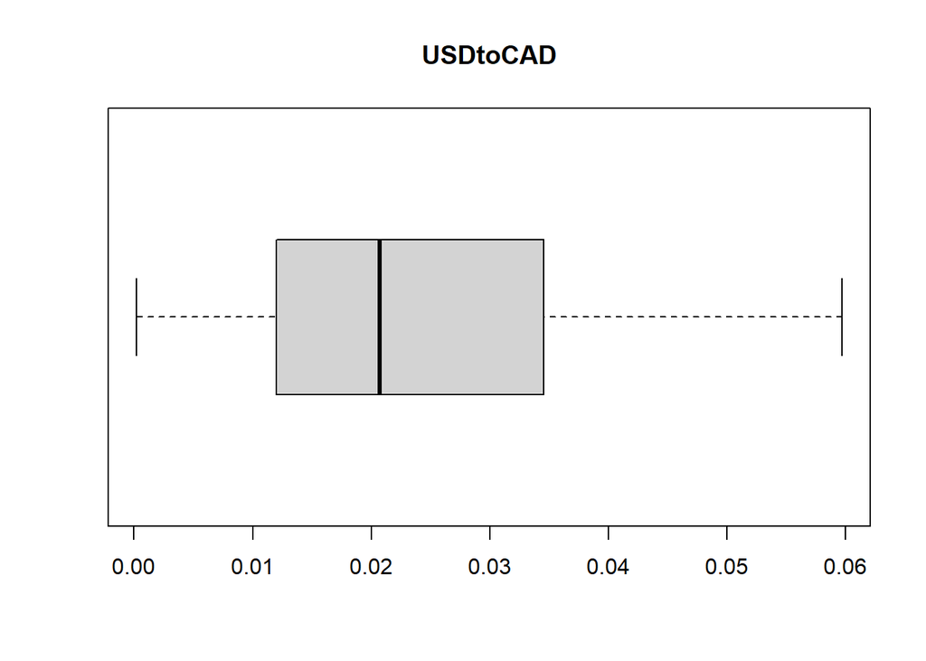

```r
boxplot(subset(dat4, select="USDtoCAD")
        , horizontal=T
        , main="USDtoCAD")
```

### (iv)函式: 計算套利空間

#### CT, Carry Trade Arbitrage

```r
CTA <- function(data3){
  index <- colnames(data3)[2:11]
  df <- data.frame(data3["Date"])
  for(i in 1:3){
    n0 <- str_sub(index[i], start=1, end=3)
    d0 <- data3[, i+1]#目標國利率
    for(j in 4:6){
      if(str_sub(index[j], start=1, end=3)==n0){
        d1 <- data3[, j+1]#目標貨幣匯率
      }else if(str_sub(index[j], start=1, end=3)=="EUR" &
               n0=="FRF"){
        d1 <- data3[, j+1]#目標貨幣匯率(歐元區)
      }
    }
    for(k in 7:9){
      if(str_sub(index[k], start=1, end=3)==n0){
        d2 <- data3[, k+1]#目標貨幣遠匯
      }else if(str_sub(index[k], start=1, end=3)=="EUR" &
               n0=="FRF"){
        d2 <- data3[, k+1]#目標貨幣遠匯(歐元區)
      }
    }
    d3 <- data3[, 11]#本國利率
    dat0 <- d2/d1*exp(d0/12)
    dat1 <- round(abs(dat0-exp(d3/12)), digits=4)
    df <- cbind(df, dat1)
  }
  colnames(df) <- c("Date"
                      , "USDtoCAD"
                      , "USDtoEUR_FRF"
                      , "USDtoGBP")
  return(df)
}
```

```r
data4 <- CTA(data3)

kable(data4) %>% kable_styling() %>% scroll_box(height="100px")
```

| Date | USDtoCAD | USDtoEUR_FRF | USDtoGBP |
| --- | --- | --- | --- |
| 01/02/2022 | 0.0034 | 0.1716 | 0.0071 |
| 01/09/2022 | 0.0088 | 0.1750 | 0.0100 |
| 01/16/2022 | 0.0208 | 0.1698 | 0.0087 |
| 01/23/2022 | 0.0086 | 0.1551 | 0.0138 |
| 01/30/2022 | 0.0085 | 0.1787 | 0.0298 |
| 02/06/2022 | 0.0117 | 0.1719 | 0.0326 |
| 02/13/2022 | 0.0117 | 0.1704 | 0.0358 |
| 02/20/2022 | 0.0083 | 0.1702 | 0.0361 |
| 02/27/2022 | 0.0161 | 0.1618 | 0.0267 |
| 03/06/2022 | 0.0190 | 0.1647 | 0.0172 |
| 03/13/2022 | 0.0123 | 0.1762 | 0.0164 |
| 03/20/2022 | 0.0168 | 0.1667 | 0.0179 |
| 03/27/2022 | 0.0162 | 0.1666 | 0.0232 |
| 04/03/2022 | 0.0195 | 0.1600 | 0.0117 |
| 04/10/2022 | 0.0544 | 0.1533 | 0.0090 |
| 04/17/2022 | 0.0315 | 0.1791 | 0.0016 |
| 04/24/2022 | 0.0451 | 0.1450 | 0.0379 |
| 05/01/2022 | 0.0350 | 0.1602 | 0.0480 |
| 05/08/2022 | 0.0173 | 0.1605 | 0.0158 |
| 05/15/2022 | 0.0194 | 0.1774 | 0.0254 |
| 05/22/2022 | 0.0124 | 0.1962 | 0.0279 |
| 05/29/2022 | 0.0418 | 0.2118 | 0.0089 |
| 06/05/2022 | 0.0276 | 0.2142 | 0.0160 |
| 06/12/2022 | 0.0209 | 0.2260 | 0.0191 |
| 06/19/2022 | 0.0165 | 0.2385 | 0.0122 |
| 06/26/2022 | 0.0100 | 0.2242 | 0.0355 |
| 07/03/2022 | 0.0588 | 0.2248 | 0.0483 |
| 07/10/2022 | 0.0475 | 0.2534 | 0.0929 |
| 07/17/2022 | 0.0256 | 0.2651 | 0.0955 |
| 07/24/2022 | 0.0294 | 0.2691 | 0.0928 |
| 07/31/2022 | 0.0165 | 0.2659 | 0.0738 |
| 08/07/2022 | 0.0206 | 0.2784 | 0.0737 |
| 08/14/2022 | 0.0248 | 0.2503 | 0.0580 |
| 08/21/2022 | 0.0215 | 0.2633 | 0.0632 |
| 08/28/2022 | 0.0304 | 0.2606 | 0.0665 |
| 09/04/2022 | 0.0597 | 0.2528 | 0.0632 |
| 09/11/2022 | 0.0532 | 0.2565 | 0.0606 |
| 09/18/2022 | 0.0505 | 0.2302 | 0.0601 |
| 09/25/2022 | 0.0414 | 0.2430 | 0.0747 |
| 10/02/2022 | 0.0125 | 0.2603 | 0.0869 |
| 10/09/2022 | 0.0024 | 0.2625 | 0.1038 |
| 10/16/2022 | 0.0317 | 0.3168 | 0.1259 |
| 10/23/2022 | 0.0038 | 0.3523 | 0.1275 |
| 10/30/2022 | 0.0056 | 0.3324 | 0.1054 |
| 11/06/2022 | 0.0002 | 0.3432 | 0.0967 |
| 11/13/2022 | 0.0285 | 0.3739 | 0.1207 |
| 11/20/2022 | 0.0454 | 0.4180 | 0.1543 |
| 11/27/2022 | 0.0057 | 0.4097 | 0.0851 |
| 12/04/2022 | 0.0341 | 0.3897 | 0.0735 |
| 12/11/2022 | 0.0408 | 0.3881 | 0.0768 |
| 12/18/2022 | 0.0575 | 0.3874 | 0.0779 |
| 12/25/2022 | 0.0233 | 0.4389 | 0.1099 |

#### 註: 以上單位均為美元(USD)

### (v)資料視覺化: 利差套利之套利空間分布

#### a. 以盒箱圖展示各國與美元組合之套利空間分布

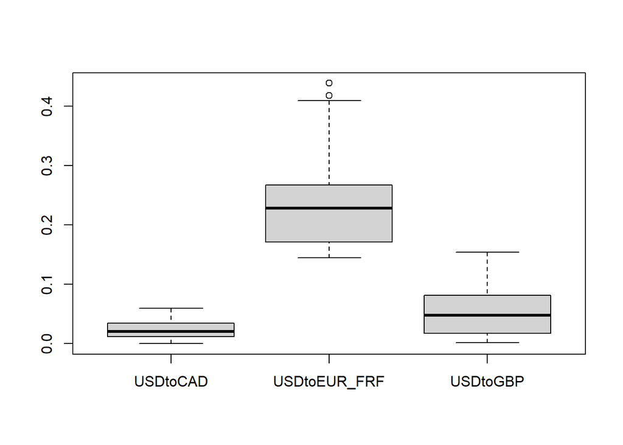

```r
boxplot(data4[2:4])
```

#### b. 以盒箱圖展示部分較為離群之組合的套利空間分布

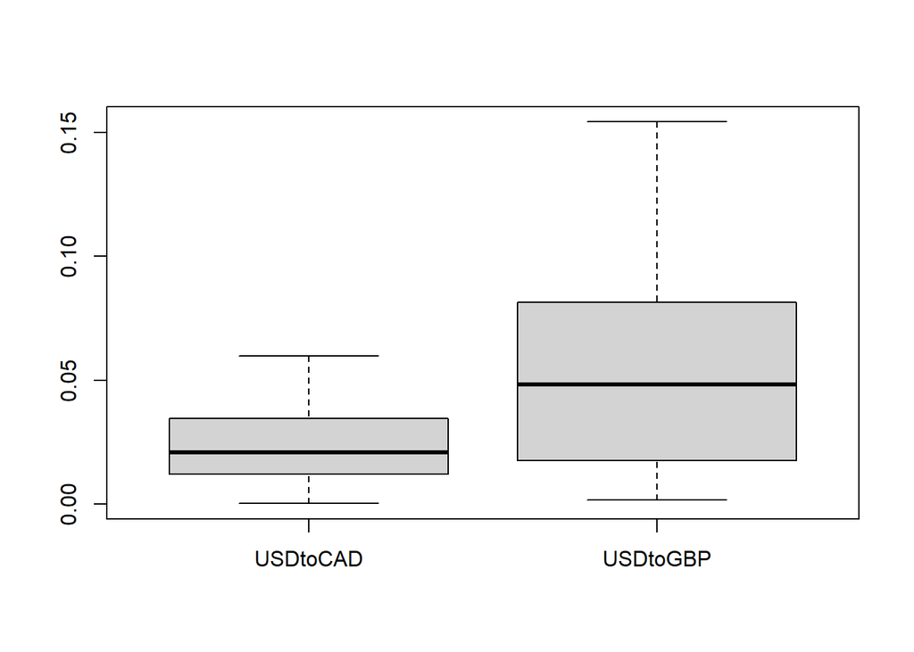

```r
datatemp13 <- data.frame(USDtoCAD=data4[, 2]
                        , USDtoGBP=data4[, 4])
boxplot(datatemp13)
```

### (vi)資料視覺化: 套利空間占比

#### 先將套利空間以0, 0.001, 0.01, 0.1, 1分成四組，再進行不同形式的比較。

```r
datatemp11 <- cut(data4[, 2]
                , breaks=c(0, 0.001, 0.01, 0.1, 1)
                , labels=c("0~0.001", "0.001~0.01", "0.01~0.1", "0.1~1")
                , include.lowest=T)
for(i in 3:4){
  temp <- cut(data4[, i]
                , breaks=c(0, 0.001, 0.01, 0.1, 1)
                , labels=c("0~0.001", "0.001~0.01", "0.01~0.1", "0.1~1")
                , include.lowest=T)
  datatemp11 <- data.frame(datatemp11, temp)
}
colnames(datatemp11) <- colnames(data4)[2:4]
```

```r
datatemp12 <- table(datatemp11[1])/53
for(i in 2:3){
  datatemp12 <- rbind(datatemp12, table(datatemp11[i])/53)
}
datatemp12 <- data.frame(datatemp12)
datatemp12 <- cbind(colnames(data4)[2:4], datatemp12)
row.names(datatemp12) <- 1:3
colnames(datatemp12) <- c("combination", "0~0.001", "0.001~0.01", "0.01~0.1", "0.1~1")
```

#### a.雷達圖(ggradar)

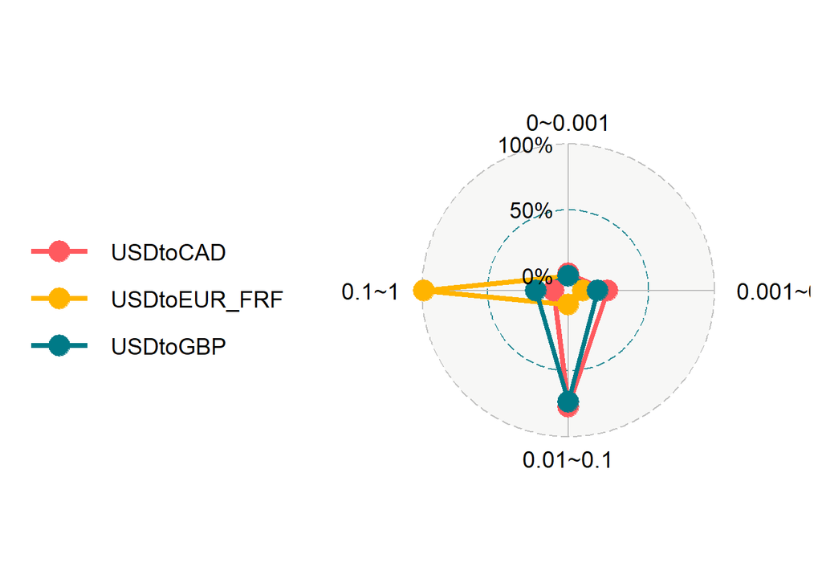

```r
datatemp12 %>% ggradar()
```

#### b.長條圖(Bar chart)

```r
temp1 <- table(datatemp11[, 1])
for(i in 2:3){
  temp1 <- rbind(temp1, table(datatemp11[, i]))
}
row.names(temp1) <- colnames(data4)[2:4]
```

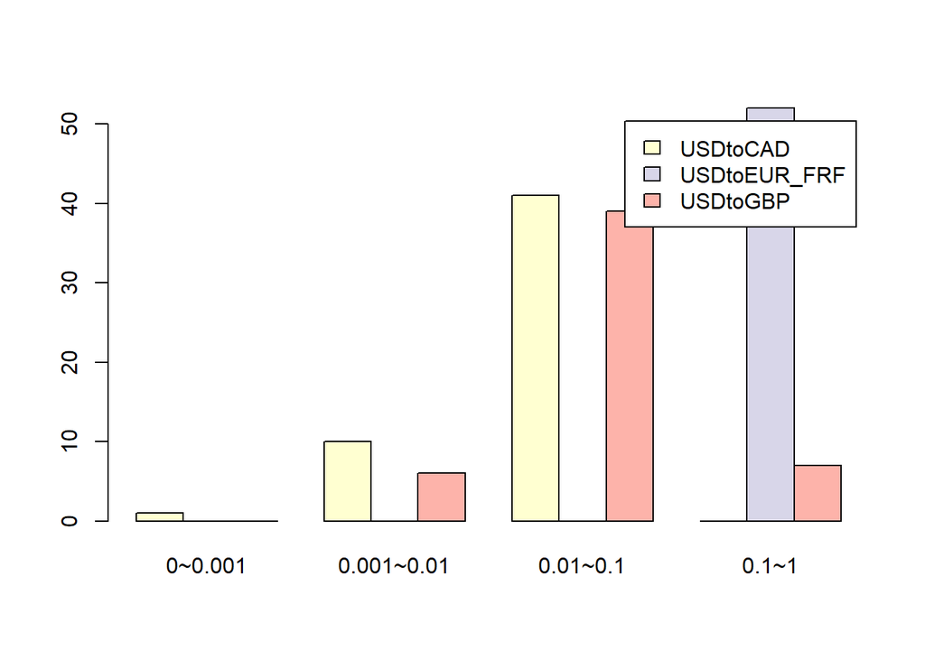

```r
temp1 %>% barplot(beside = T
                 , legend.text = rownames(.)
                 , col = palette("Set 3")[2:4] %>% alpha(0.6))
```

#### c.熱量圖(Heat map)

```r
datatemp13 <- table(datatemp11[1])/53
for(i in 2:3){
  datatemp13 <- rbind(datatemp13, table(datatemp11[i])/53)
}
datatemp13 <- data.frame(datatemp13)
row.names(datatemp13) <- colnames(data4)[2:4]
colnames(datatemp13) <- c("0~0.001", "0.001~0.01", "0.01~0.1", "0.1~1")
```

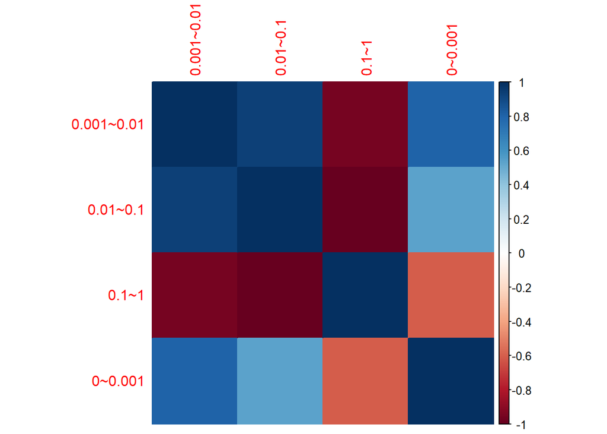

```r
corrplot(cor(datatemp13), method = 'color', order = 'alphabet')
```

### (vii)資料分析: 各國與美元組合套利空間之One-Way ANOVA

```r
fit1 <- lm(USDtoCAD~USDtoEUR_FRF+USDtoGBP, data=data4)
fit1 <- anova(fit1)
kable(fit1, "pipe", align = "cccc")
```

|  | Df | Sum Sq | Mean Sq | F value | Pr(>F) |
| --- | --- | --- | --- | --- | --- |
| USDtoEUR_FRF | 1 | 0.0002831 | 0.0002831 | 1.0342155 | 0.3141659 |
| USDtoGBP | 1 | 0.0000019 | 0.0000019 | 0.0068675 | 0.9342921 |
| Residuals | 49 | 0.0134110 | 0.0002737 | NA | NA |

### https://6842studio.shinyapps.io/final3/

#### (建議按右鍵以開啟新分頁)

# 陸、結論

### (iii) ANOVA分析

#### 變異數分析的目的在於比較不同子群體的均值是否在統計檢定下相同。在三角套利下，設比較對象為英鎊與日幣的組合(GBP_JPY)，其餘子群體的p-value均低於0.05，代表子群體之均值不同；在利差套利下，設比較對象為美元對加幣的組合(USDtoCAD)，其餘子群體的p-value均不低於0.05，代表子群體之均值相同。

# 柒、指定問題

### (i)Where you get your project ideas?

#### 學生在大二下時決定輔修本校經濟學系，修課計畫隨之變更，加上當時想要挑戰自我，因此在尚未修習衍生性金融商品與衍生性商品訂價的情況下選修本系曾祺峰教授所開授之國際財務管理。在這門課上學到許多外匯的知識，其中最吸引我的題材即是外匯套利。然而當時曾教授提及此處時，多次提及套利機會的出現都是一閃即逝，一經出現，馬上就會被敏銳的投機者以大量下單所導致的供需改變而填平，這激發了我想要建立快速計算多筆貨幣、期貨和利率組合下之套利空間的程式工具。

### (ii)How many new packages and functions are used?(other than those from PresTree lecture notes)

#### a. shiny: 用於建立互動式頁面

#### b. rsconnect: 用於將shiny互動式頁面發布至shinyapps.io，可更彈性地使用互動式頁面、不用開啟本報告即可使用與分析。

#### c. ggradar: 繪製雷達圖

### (iii)What is the most difficult part of your analysis?

#### 我認為完成這份報告最難的部分是建立處理三角套利計算與利差套利計算的函數。因為這涉及到對資料結構、位置的精確認知與對所有可能情況的掌握。如計算利差套利時，就要特別考量到歐元區國家使用的是歐元、利率則是採用該國所發行之債券。另外在找尋利差套利的資料時，資料收集也是一大難題。基於尋求較為廣泛的條件，因此我只尋找一年有12期的期貨外匯期貨、而排除掉一年4期者；利率亦同，僅納入有一月期者。

# 捌、參考資料

### (i)International Financial Management, 13e

#### ISBN：9789869508216

### (ii)外匯套利

#### ISBN : 9789866320293

# 玖、報告原始碼與所有資料

### https://drive.google.com/drive/folders/1aKWVPqnqEFaoq5VLCDqTLqTYCaWyrYdS?usp=drive_link